# Stat 202: Lecture 11 (covers pp. 138-155)

Nathan VanHoudnos  
10/17/2014

### Agenda

1. Homework comments
2. Checkpoint #12 results
3. Lecture 11 (covers pp. 138-155)

### Homework comments

### Agenda

1. Homework comments
2. Checkpoint #12 result
3. Lecture 11 (covers pp. 128-155)

### Question 2 Checkpoint #12

The random variable X, representing the number of accidents in a certain intersection in a week, has the following probability distribution:

```r
x     |    0|    1|    2|    3|    4|    5|
-------------------------------------------
P(X=x)| 0.20| 0.30| 0.20| 0.15| 0.10| 0.05|
```

By the third day of a particular week, 2 accidents have already occurred in the intersection. What is the probability that there will be less than a total of 4 accidents during that week?

### Answer

By the third day of a particular week, 2 accidents have already occurred in the intersection. What is the probability that there will be less than a total of 4 accidents during that week?

```r
x     |    0|    1|    2|    3|    4|    5|
-------------------------------------------
P(X=x)| 0.20| 0.30| 0.20| 0.15| 0.10| 0.05|
```

“Two accident have already occurred” implies that at least two accidents will occur this week. We condition on \( X \ge 2 \).

The “less than a total of 4” implies \( X < 4 \)

Therefore we want \( P(X < 4|X \ge 2) \).

### Answer

By definition \( P(X < 4|X \ge 2) \) is

\[ P(X < 4|X \ge 2) = \frac{P( X < 4 \text{ and } X \ge 2 )}{P(X \ge 2)} \]

The only counts less than 4 and greater than or equal to 2 are 2 and 3:

\[ P( X < 4 \text{ and } X \ge 2 ) = P(X =2 ) + P(X = 3) \]

### Answer

By the third day of a particular week, 2 accidents have already occurred in the intersection. What is the probability that there will be less than a total of 4 accidents during that week?

```r
x     |    0|    1|    2|    3|    4|    5|
-------------------------------------------
P(X=x)| 0.20| 0.30| 0.20| 0.15| 0.10| 0.05|
```

\[ \begin{aligned} P(X < 4|X \ge 2) & = \frac{P(X =2 ) + P(X = 3)}{P(X \ge 2)} \\ & = \frac{.2 + .15}{.20 + .15 +.10 +.05} \\ & = \frac{.35}{.5} = .70 \end{aligned} \]

### Agenda

1. Homework comments
2. Checkpoints #12 result
3. Lecture 11 (covers pp. 128-155)
   - **Checkpoint 13: Expection and variance rules** (finish today, slides marked with R are review)
   - Checkpoint 15: Normal random variables

### (R) Expected value rules

Let \( Y = X + 6 \) be a new random variable.

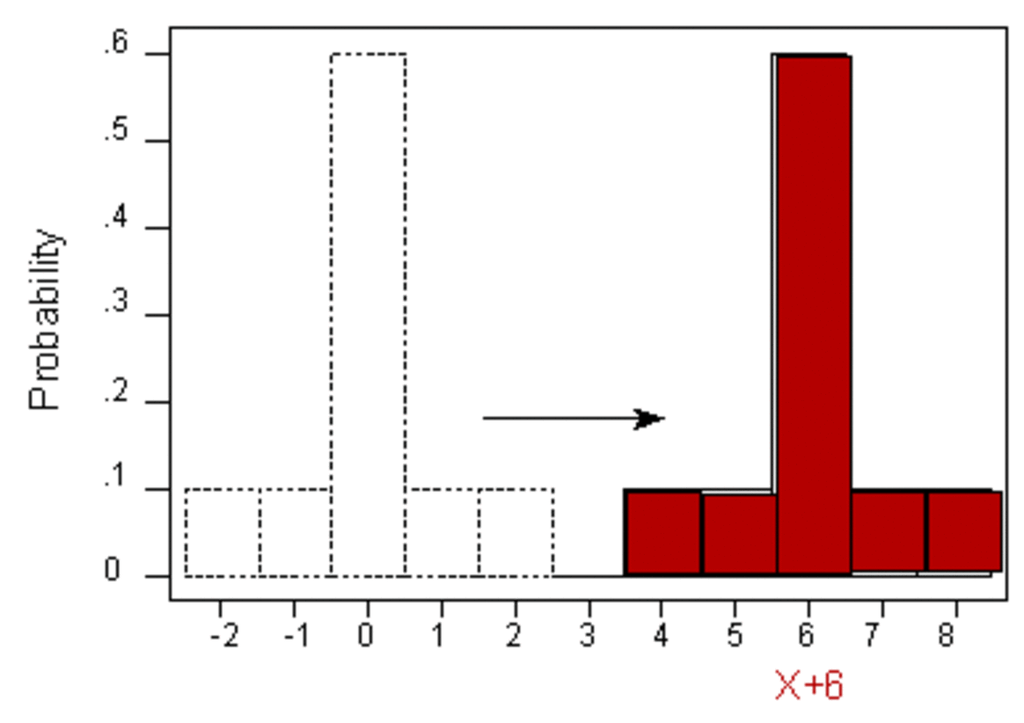

Is \( E[Y] = E[X] + 6 \)?

### $$\text{(R) Let } Y = X + a \quad E[Y] = ?$$

\[ \begin{aligned} E[Y] & = \sum y \cdot P(Y=y) \\ & = \sum (x + a) \cdot P(X + a = x + a) \\ & = \sum (x + a) \cdot P(X = x) \\ & = \left( \sum x \cdot P(X=x) \right ) + \left( \sum a \cdot P(X=x) \right) \\ & = E[X] + a \cdot \left(\sum P(X=x) \right) \\ & = E[X] + a \end{aligned} \]

### (R) Expected value rules

Let \( Y = 4X \) be a new random variable.

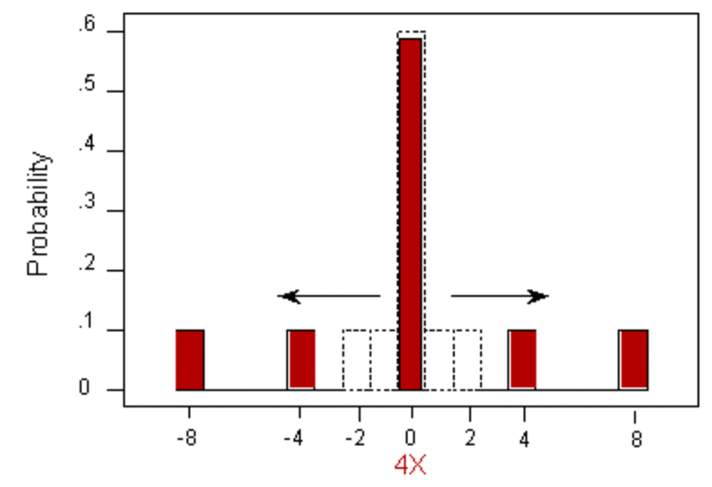

Is \( E[Y] = 4 \cdot E[X] \)?

### $$\text{(R) Let } Y = b X \quad E[Y] = ?$$

\[ \begin{aligned} E[Y] & = \sum y \cdot P(Y=y) \\ & = \sum (x b ) \cdot P(X b = x b) \\ & = \sum (x b) \cdot P(X = x) \\ & = b \cdot \left( \sum x \cdot P(X=x) \right ) \\ & = b \cdot E[X] \end{aligned} \]

### $$\text{(R) Let } Y = a + b X \quad E[Y] = ?$$

We can combine these rules:

\[ \begin{aligned} E[Y] & = E[a + b X] \\ & = a + E[ b X] \\ & = a + b \cdot E[X] \end{aligned} \]

### An example

At StatsPie, the number of toppings on the typical pizza is a random variable X having a mean value of 3. The cost of a pizza is $10 plus $1.50 per topping. How much does the average customer spend on a pizza?

\[ \begin{aligned} E[X] & = 3 & Y & = 10 + 1.5 X \end{aligned} \]

\[ \begin{aligned} E[Y] & = E[10 + 1.5 X] \\ & = 10 + 1.5 \cdot E[X] \\ & = 10 + 1.5 \cdot 3 = 14.50 \end{aligned} \]

implying the average pizza costs $14.50.

### Variance

Let the **variance** of the random variable \( X \) be defined as

\[ \text{Var}[X] = E\left[ \left(X - E[X]\right)^2 \right] \]

i.e. the **expected value** of the **squared distance from the mean**.

Using the rules for expected values we derive the following identity:

\[ \text{Var}[X] = E[X^2] ~ - ~ \left( E[X] \right)^2 \]

which is easier to calculate by hand.

### Example

\[ \begin{aligned} \text{Var}[X] & = E[X^2] ~ - ~ \left( E[X] \right)^2 \\ % E[X] & = \sum_{x \in S} x \cdot P(X = x) \\ % E[X^2] & = \sum_{x \in S} x^2 \cdot P(X = x) \end{aligned} \]

```r
x       |   0|   1|   2|   3|   4|   5|
--------+----+----+----+----+----+----|
P(X = x)| .28| .37| .23| .09| .02| .01|
```

\[ \begin{aligned} E[X] & = \sum_{x \in S} x \cdot P(X = x) \\ & = ~ 0 \times .28 + 1 \times .37 + 2 \times .23 \\ & ~ + \! 3 \times .09 + 4 \times .02 + 5 \times .01 \\ & = 1.23 \end{aligned} \]

### Example

\[ \begin{aligned} \text{Var}[X] & = E[X^2] ~ - ~ \left( E[X] \right)^2 \\ % E[X] & = \sum_{x \in S} x \cdot P(X = x) \\ % E[X^2] & = \sum_{x \in S} x^2 \cdot P(X = x) \end{aligned} \]

```r
x       |   0|   1|   2|   3|   4|   5|
--------+----+----+----+----+----+----|
P(X = x)| .28| .37| .23| .09| .02| .01|
```

\[ \begin{aligned} E[X^2] & = \sum_{x \in S} x^2 \cdot P(X = x) \\ & = ~ 0^2 \times .28 + 1^2 \times .37 + 2^2 \times .23 \\ & ~ + \! 3^2 \times .09 + 4^2 \times .02 + 5^2 \times .01 \\ & = 2.67 \end{aligned} \]

### Example

\[ \begin{aligned} E[X] & = 1.23 & E[X^2] & = 2.67 \end{aligned} \]

```r
x       |   0|   1|   2|   3|   4|   5|
--------+----+----+----+----+----+----|
P(X = x)| .28| .37| .23| .09| .02| .01|
```

\[ \begin{aligned} \text{Var}[X] & = E[X^2] - \left( E[X] \right)^2 \\ & = 2.67 - (1.23)^2 \\ & = 1.16 \end{aligned} \]

implying that college students change their majors on average 1.23 times with a **variance** of 1.16 “times-squared”.

### "Times-squared" is a weird unit

Let the **standard deviation** be the square root of the variance.

\[ \text{sd}[X] = \sqrt{\text{Var}[X]} \]

Example:

\[ \begin{aligned} \text{sd}[X] & = \sqrt{\text{Var}[X]} \\ & = \sqrt{1.16} & = 1.078 \end{aligned} \]

implying that college students change their majors on average 1.23 times with a **standard deviation** of 1.08 times.

### Rules for standard deviation

Using the rules for expectations, we can show that:

\[ \text{Var}[a + bX] = b^2 \cdot \text{Var}[X] \]

Therefore

\[ \text{sd}[a + bX] = b \cdot \text{sd}[X] \]

### Example

At StatsPie, the number of toppings on the typical pizza has a mean value of 3 with a standard deviation of ½. The cost of a pizza is $10 plus $1.50 per topping.

What are the mean and standard deviation of the distribution of pizza cost?

\[ \begin{aligned} E[X] & = 3 & \text{sd}[X] & = 0.5 \\ Y & = 10 + 1.5 X \\ E[Y] & = ? & \text{sd}[Y] & = ? \end{aligned} \]

### Example

\[ \begin{aligned} E[X] & = 3 & \text{sd}[X] & = 0.5 \\ Y & = 10 + 1.5 X \\ \end{aligned} \]

Recall that \( E[Y] = 14.50 \).

Find the standard deviation:

\[ \begin{aligned} \text{sd}[Y] & = \text{sd}[10 + 1.5 X] \\ & = 1.5 \cdot \text{sd}[X] \\ & = 1.5 \cdot 0.5 = .75 \end{aligned} \]

### Example

At StatsPie, the number of toppings on the typical pizza has a mean value of 3 with a standard deviation of ½. The cost of a pizza is $10 plus $1.50 per topping.

What are the mean and standard deviation of the distribution of pizza cost?

\[ \begin{aligned} E[Y] & = 14.50 & \text{sd}[Y] & = .75 \end{aligned} \]

implying that the pizza typically costs an average of $14.50 with a standard deviation of $0.75.

### Adding two random variables

Let \( X \) and \( Y \) be random variables and define \( Z = X + Y \) and \( Q = X - Y \).

It can be shown that, in all cases:

\[ \begin{aligned} E[Z] & = E[X] + E[Y] \\ E[Q] & = E[X] - E[Y] \end{aligned} \]

And, **if and only if X and Y are independent**, that

\[ \begin{aligned} \text{Var}[Z] & = \text{Var}[X] + \text{Var}[Y]\\ \text{Var}[Q] & = \text{Var}[X] + \text{Var}[Y] \end{aligned} \]

### Standard deviations do not add

**If and only if X and Y are independent**, then

\[ \begin{aligned} \text{Var}[Z] & = \text{Var}[X] + \text{Var}[Y]\\ \text{Var}[Q] & = \text{Var}[X] + \text{Var}[Y] \end{aligned} \]

Further note that, **iff X and Y are independent** \[ \begin{aligned} \text{sd}[Z] & = \sqrt{\text{Var}[X] + \text{Var}[Y]}\\ \text{sd}[Q] & = \sqrt{\text{Var}[X] + \text{Var}[Y]} \end{aligned} \]

> Standard deviations **DO NOT** add.

### What if X and Y are dependent?

**Not covered in Stat 202.**

Answer:

Let \( X \) and \( Y \) be random variables and define \( Z = aX + bY + c \).

\[ \text{Var}[Z] = a^2 \cdot \text{Var}[X] + b^2 \cdot \text{Var}[Y] - 2ab \cdot \text{Cov}[X,Y] \]

where

\[ \text{Cov}[X,Y] = E\big[ \left( X - E[X] \right) \cdot \left( Y - E[Y] \right) \big] \]

### Agenda

1. Homework comments
2. Checkpoints #12 result
3. Lecture 11 (covers pp. 128-155)
   - Checkpoint 13: Exception and variance rules
   - **Checkpoint 15: Normal random variables**

### Transition to continuous RVs

IQ: 2 categories

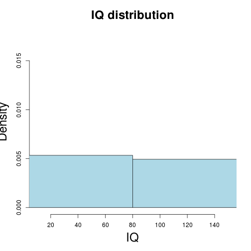

IQ: 3 categories

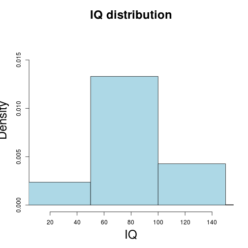

### Transition to continuous RVs

and lots more…

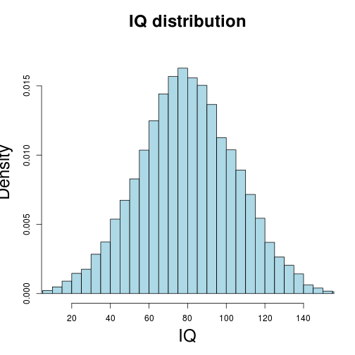

and infinitely more…

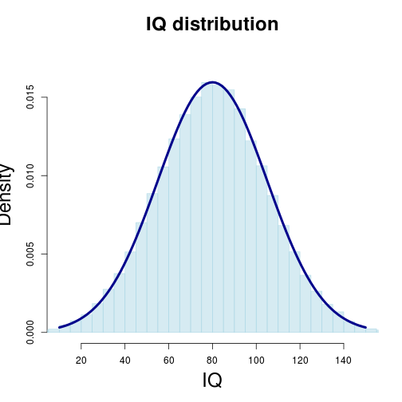

### Density curves

**A normal density**

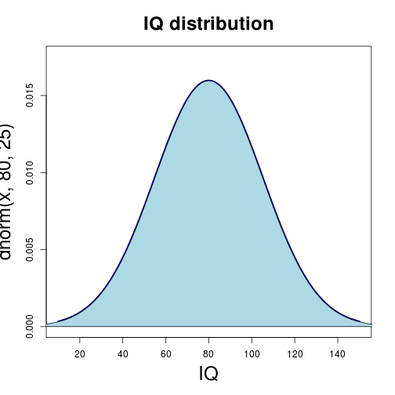

A density curve is the limit of a probability histogram.

- The area under the curve is the **probability**.
- The total area is 1.

For now, we study a special case:

- **normal distributions**

### Normal Distributions

If \( X \) is a **normally distributed** random variable:

- \( X + a \) is also normally distributed
- \( bX \) is also normally distributed
- \( a + bX \) is also normally distributed.

A normal distribution is completely defined by its **mean** and its **variance**.

- finding the distribution of \( a + bX \) is as simple as using the \( E[...] \) and \( \text{Var}[...] \) rules.

### Example

Let \( X \) be normally distributed with mean 100 and variance of 9.

\[ X \sim N(100, 9) \]

What is the distribution of \( A = X-100 \)?

\[ E[A] = E[X-100] = E[X] - 100 = 100 - 100 = 0 \]

\[ \text{Var}[A] = \text{Var}[X-100]=\text{Var}[X]=9 \]

Therefore, \( A \) is normally distributed with a mean of 0 and a variance of 9.

\[ A \sim N(0,9) \]

### Example

\[ X \sim N(100,9) \quad \quad A \sim N(0,9) \]

What is the distribution of \( B = \frac{A}{\sqrt{9}} = \frac{X-100}{\sqrt{9}} \)?

\[ E[B] = E[\frac{A}{\sqrt{9}}] = \frac{1}{\sqrt{9}}E[A] = \frac{1}{\sqrt{9}} \cdot 0 = 0 \]

\[ \text{Var}[B] = \text{Var}[\frac{A}{\sqrt{9}}]=\left(\frac{1}{\sqrt{9}}\right)^2\text{Var}[A]=\frac{1}{9}\cdot 9 = 1 \]

Therefore, \( B \) is normally distributed with a mean of 0 and a standard deviation of 1.

\[ B \sim N(0,1) \]

### Example

\[ X \sim N(100,9) \quad \quad A \sim N(0,9) \]

What is the distribution of \( B = \frac{A}{\sqrt{9}} = \frac{X-100}{\sqrt{9}} \)?

\[ E[B] = 0 \quad \quad \text{Var}[B] = 1 \]

Therefore, \( B \) is normally distributed with a mean of 0 and a standard deviation of 1.

\[ B \sim N(0,1) \]

### The standard normal distribution

Any normal distribution can be transformed to a standard normal

Let \( X \sim N(\mu, \sigma^2) \) where \( \mu \) is the mean and \( \sigma^2 \) the variance.

Let \[ Z = \frac{X - E[X]}{\text{sd}[X]} = \frac{X - \mu}{\sqrt{\sigma^2}} \]

\( Z \) is a standard normal, its mean is zero and its variance is 1.

### A std normal uses sd as a ruler

At StatsPie, the amount of cheese used to make a typical pizza is normally distributed with a mean value of 6 oz with a variance of ¼ oz. What is the z-score for a pizza that will use at least 7 oz of cheese?

Let \( X \sim N(6, 1/4) \) and \( Z = \frac{X - 6}{\sqrt{1/4}} \)

If \( X = 7 \) then \( Z = ? \)

\[ Z = \frac{7-6}{\sqrt{1/4}} = \frac{1}{1/2} = 2 \]

implying that 7 is two standard deviations from the mean.

### Recall: the 68-95-99.7 rule

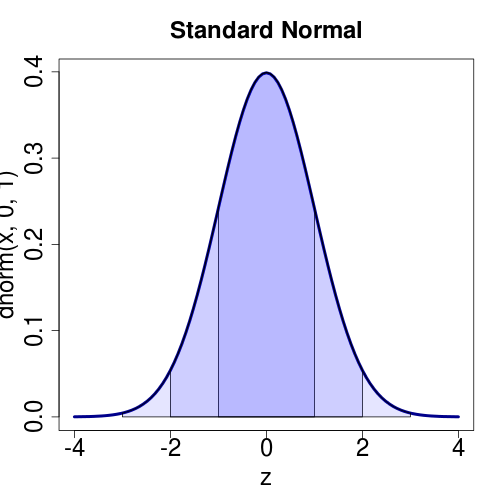

Percentages of observations:

- 68% within 1 sd
- 95% within 2 sd
- 99.7% within 3 sd

### An example

At StatsPie, the amount of cheese used to make a typical pizza is normally distributed with a mean value of 6 oz with a variance of ¼ oz. What is the probability that a pizza will use at least 7 oz of cheese?

“at least 7 oz of cheese” means \( X \ge 7 \)

\[ P(X \ge 7) = ? \]

implying that \( x = 7 \) oz is \( z = 2 \) standard deviations from the mean.

### An example

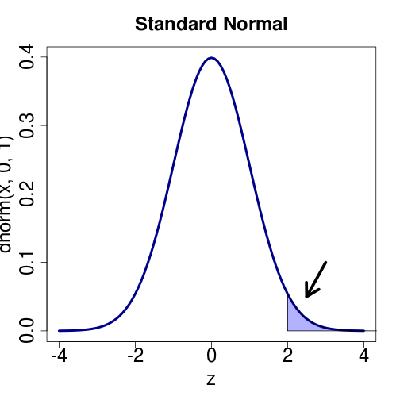

\( P(X \ge 7) = P(Z \ge 2) = ? \)

The probability of \( Z \) being greater than or equal to 2 is the shaded area.

The 68-95-99.7 rule says that 95% of observations are within 2 sd.

Therefore 2.5% of observations are **above** 2 sd.

### An example

At StatsPie, the amount of cheese used to make a typical pizza is normally distributed with a mean value of 6 oz with a variance of ¼ oz. What is the probability that a pizza will use at least 7 oz of cheese?

\( P(X \ge 7) = P(Z \ge 2) = .025 \)

implying that 2.5% of pizza will use at least 7 oz of cheese.

### A Stat 202 rule of thumb

> **Typical** values of a random variable are within 2 standard deviations of the mean.
- The 68–95–99.7 rule states that 95% of observations from a **normal distribution** are within two standard deviations of the mean.
- [Chebyshev's inequality](http://en.wikipedia.org/wiki/Chebyshev's_inequality) (not covered in Stat 202) states that **at least** 75% of observations from **any probability distribution** are within two standard deviations of the mean.

### An further example

At StatsPie, the amount of cheese used to make a typical pizza is normally distributed with a mean value of 6 oz with a variance of ¼ oz. What is the probability that a pizza will use at least 7.34 oz of cheese?

\[ \begin{aligned} P(X \ge 7.34) & = P(X - 6 \ge 7.34 - 6) \\ & = P(\frac{X - 6}{\sqrt{1/4}} \ge \frac{7.34 - 6}{\sqrt{1/4}}) \\ & = P(Z \ge 2.68 ) \end{aligned} \]

where \( Z \) is distributed as a standard normal.

### Extending the 68–95–99.7 rule

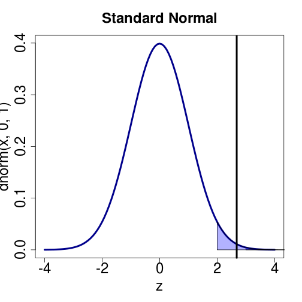

We know that \( P(Z \ge 2.68 ) \) will be somewhere between 2.5% and 0.15%.

What is it?

- A famous result in calculus is that **there is no closed form formula** for the area under a normal curve.
- Use a table (or software)

### A standard normal table

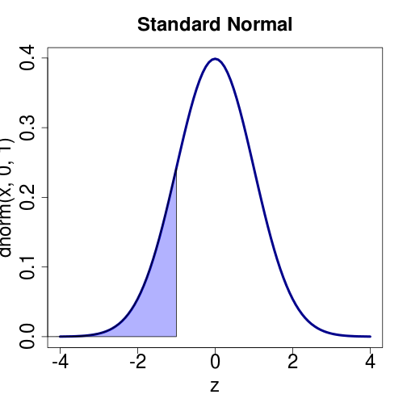

Gives the area to the left of \( z \).

To use:

1. Express your z-score as **less than**.
2. Find the **row** with the first two digits of \( z \).
3. Find the **column** with the third digit of \( z \)
4. Read off the value.

Best explained by looking at one.

### Example

Step 1:

\( P(Z \ge 2.68 ) = 1 - P(Z \le 2.68 ) \)

Step 2: \( 2.68 = 2.6 + 0.08 \) find \( 2.6 \)

| z | .00 | .01 | .02 | .03 | .04 | .05 | .06 | .07 | .08 | .09 |
| --- | --- | --- | --- | --- | --- | --- | --- | --- | --- | --- |
| 2.5 | .9938 | .9940 | .9941 | .9943 | .9945 | .9946 | .9948 | .9949 | .9951 | .9952 |
| 2.6 | .9953 | .9955 | .9956 | .9957 | .9959 | .9960 | .9961 | .9962 | .9963 | .9964 |
| 2.7 | .9965 | .9966 | .9967 | .9968 | .9969 | .9970 | .9971 | .9972 | .9973 | .9974 |

We want:

| z | .00 | .01 | .02 | .03 | .04 | .05 | .06 | .07 | .08 | .09 |
| --- | --- | --- | --- | --- | --- | --- | --- | --- | --- | --- |
| 2.6 | .9953 | .9955 | .9956 | .9957 | .9959 | .9960 | .9961 | .9962 | .9963 | .9964 |

### Example

Step 1: \( P(Z \ge 2.68 ) = 1 - P(Z \le 2.68 ) \)

Step 2: \( 2.68 = 2.6 + 0.08 \) find \( 2.6 \)

| z | .00 | .01 | .02 | .03 | .04 | .05 | .06 | .07 | .08 | .09 |
| --- | --- | --- | --- | --- | --- | --- | --- | --- | --- | --- |
| 2.6 | .9953 | .9955 | .9956 | .9957 | .9959 | .9960 | .9961 | .9962 | .9963 | .9964 |

Step 3: \( 2.68 = 2.6 + 0.08 \) find \( 0.08 \)

| z | .08 |
| --- | --- |
| 2.6 | .9963 |

Solve:

\( P(Z \ge 2.68 ) = 1 - P(Z \le 2.68 ) = 1 - .9963 = 0.0037 \)

### Pulling it together

At StatsPie, the amount of cheese used to make a typical pizza is normally distributed with a mean value of 6 oz with a variance of ¼ oz. What is the probability that a pizza will use at least 7.34 oz of cheese?

\[ \begin{aligned} P(X \ge 7.34) & = P(Z \ge 2.68 ) \\ & = 1 - P(Z \le 2.68 ) \\ & = 1 - .9963 = 0.0037 \end{aligned} \]

implying that only 0.37% of pizzas will use at least 7.34 oz of cheese.

### Using R

At StatsPie, the amount of cheese used to make a typical pizza is normally distributed with a mean value of 6 oz with a variance of ¼ oz. What is the probability that a pizza will use at least 7.34 oz of cheese?

Find the z-score:

```r
(7.34-6)/sqrt(1/4)
```

```
[1] 2.68
```

### Using R

At StatsPie, the amount of cheese used to make a typical pizza is normally distributed with a mean value of 6 oz with a variance of ¼ oz. What is the probability that a pizza will use at least 7.34 oz of cheese?

Lookup \( P(Z \le 2.68) \)

```r
pnorm( 2.68 )
```

```
[1] 0.9963
```

### Using R

At StatsPie, the amount of cheese used to make a typical pizza is normally distributed with a mean value of 6 oz with a variance of ¼ oz. What is the probability that a pizza will use at least 7.34 oz of cheese?

Find \( P(Z \ge 2.68) = 1 - (Z \le 2.68) \)

```r
1 - pnorm( 2.68 )
```

```
[1] 0.003681
```

implying that 0.37% of pizzas use at least 7.34 oz of cheese.

### Going the other way

At StatsPie, the amount of cheese used to make a typical pizza is normally distributed with a mean value of 6 oz with a variance of ¼ oz. How much cheese would the top 10% of pizzas contain?

We know that:

\[ P(X \ge x) = .1 \]

what is \( x \)?

### Going the other way

\[ \begin{aligned} P(X \ge x) & = .10 \\ & = P(\frac{X - 6}{\sqrt{1/4}} \ge \frac{x - 6}{\sqrt{1/4}}) \\ & = P(Z \ge z ) = .10 \end{aligned} \]

To find the correct \( z \) value we express it as less than:

\[ P(Z \ge z) = .1 = 1 - P(Z \le z) \]

Implying that we need to lookup

\[ P(Z \le z) = 1 - .1 = .90 \]

in our table.

### Going the other way

| z | .00 | .01 | .02 | .03 | .04 | .05 | .06 | .07 | .08 | .09 |
| --- | --- | --- | --- | --- | --- | --- | --- | --- | --- | --- |
| 1.2 | .8849 | .8869 | .8888 | .8907 | .8925 | .8944 | .8962 | .8980 | .8997 | .9015 |
| 1.3 | .9032 | .9049 | .9066 | .9082 | .9099 | .9115 | .9131 | .9147 | .9162 | .9177 |

That is somewhat unsatisfying…

- \( P(Z \le 1.28) = .8997 \) and
- \( P(Z \le 1.29) = .9015 \)

Choose \( 1.28 \) as its probability is closer to .90.

### Going the other way

We wanted: \( P(Z \le z) = 1 - .1 = .90 \)

We have: \( P(Z \le 1.28) = .8997 \).

Just go with it. Therefore: \[ \begin{aligned} P(X \ge x) & = .10 \\ & = P(\frac{X - 6}{\sqrt{1/4}} \ge \frac{x - 6}{\sqrt{1/4}}) \\ & = P(Z \ge 1.28 ) = .10 \end{aligned} \]

So solve: \( \frac{x - 6}{\sqrt{1/4}} = 1.28 \)

### Going the other way

\[ \frac{x - 6}{\sqrt{1/4}} = 1.28 \]

Implies \[ x = 6 + 1.28 \sqrt{1/4} = 6.64 \]

### Pulling it together

At StatsPie, the amount of cheese used to make a typical pizza is normally distributed with a mean value of 6 oz with a variance of ¼ oz. How much cheese would the top 10% of pizzas contain?

\[ P(X \ge x) = .1 \]

\[ x = 6 + 1.28 \sqrt{1/4} = 6.64 \]

implies that at least 6.64 oz of cheese are used to make the top 10% of pizzas.

### Using R

At StatsPie, the amount of cheese used to make a typical pizza is normally distributed with a mean value of 6 oz with a variance of ¼ oz. How much cheese would the top 10% of pizzas contain?

\[ P(X \ge x) = .1 \]

Express the z-score probability as a less than:

\[ P(Z \ge z) = 1 - P(Z \le z) = .1 \]

\( P(Z \le z) = .90 \)

### Using R

At StatsPie, the amount of cheese used to make a typical pizza is normally distributed with a mean value of 6 oz with a variance of ¼ oz. How much cheese would the top 10% of pizzas contain?

Look \( P(Z \le z) = .90 \) up in R

```r
qnorm(.90)
```

```
[1] 1.282
```

implying that the z score is \( 1.282 \).

### Using R

At StatsPie, the amount of cheese used to make a typical pizza is normally distributed with a mean value of 6 oz with a variance of ¼ oz. How much cheese would the top 10% of pizzas contain?

Convert \( z = 1.282 \) to the units of X.

```r
6 + sqrt(1/4) * 1.282
```

```
[1] 6.641
```

implying that the top 10% of pizzas use at least \( 6.64 \) of cheese.

### A further example

At StatsPie, the amount of cheese used to make a typical pizza is normally distributed with a mean value of 6 oz with a variance of ¼ oz. What is the probability of getting a pizza that has between 5.4 and 6.7 ounces of chese?

\[ P(5.4 \le X \le 6.7) = ? \]

Draw a picture to express it in terms of “less than”:

\[ P(5.4 \le X \le 6.7) = P(X \le 6.7) - P(X \le 5.4) \]

### Picture

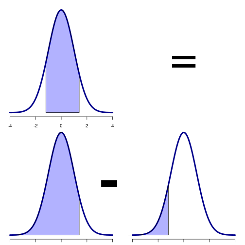

\[ \begin{aligned} P(& 5.4 \le X \le 6.7) = \\ & P(X \le 6.7) - P(X \le 5.4) \end{aligned} \]

Since you already know how to solve the “less than” problems, you can solve this problem too.

### Solution

\( P(X \le 6.7) = P(\frac{X-6}{\sqrt{1/4}} \le \frac{6.7-6}{\sqrt{1/4}}) = P(Z \le 1.4) \)

```r
pnorm(1.4)
```

```
[1] 0.9192
```

\( P(X \le 5.4) = P(\frac{X-6}{\sqrt{1/4}} \le \frac{5.4-6}{\sqrt{1/4}}) = P(Z \le -1.2) \)

```r
pnorm(-1.2)
```

```
[1] 0.1151
```

### Pulling it together

At StatsPie, the amount of cheese used to make a typical pizza is normally distributed with a mean value of 6 oz with a variance of ¼ oz. What is the probability of getting a pizza that has between 5.4 and 6.7 ounces of chese?

\[ \begin{aligned} P(5.4 \le X \le 6.7) & = P(X \le 6.7) - P(X \le 5.4) \\ & = 0.9192 - 0.1151 \\ & = 0.8041 \end{aligned} \]

implying that 80% of pizzas contain between 5.4 and 6.7 oz of cheese.

### Normal Summary

Normal problems look something like this:

- Convert to a standard normal
- Express the probabilities in terms of less than
- Lookup either the probability or z-score in the table
- Convert back to the original distribution (if needed)

### Fun Calculus fact

The density function of a normal random variable with a mean of \( \mu \) and a standard deviation \( \sigma \) is \[ f(x) = \frac{1}{\sigma \sqrt{2\pi }} e^{- \frac{(x-\mu)^2}{2\sigma^2}} \]

The probability of \( X \) being between two constants \( a \) and \( b \) is: \[ P(a \le X \le b) = \int_a^b \frac{1}{\sigma \sqrt{2\pi }} e^{- \frac{(x-\mu)^2}{2\sigma^2}} dx \]

This integral has **no closed form solution**.

> I **cannot** give you a non-integral formula.